# The Wreck of the Titan Sentiment Analysis

The bing lexicon was also used to compare its results with the results obtained from the nrc lexicon.

```r
bing <- get_sentiments("bing")

titanic6 <- titanic %>%
  select(-c("n", "total")) %>%
  inner_join(bing)
head(titanic6) %>%
  kable()
```

| word | sentiment |
| --- | --- |
| well | positive |
| good | positive |
| right | positive |
| like | positive |
| work | positive |
| enough | positive |

The plot of the positive words versus the negative words was as shown below;

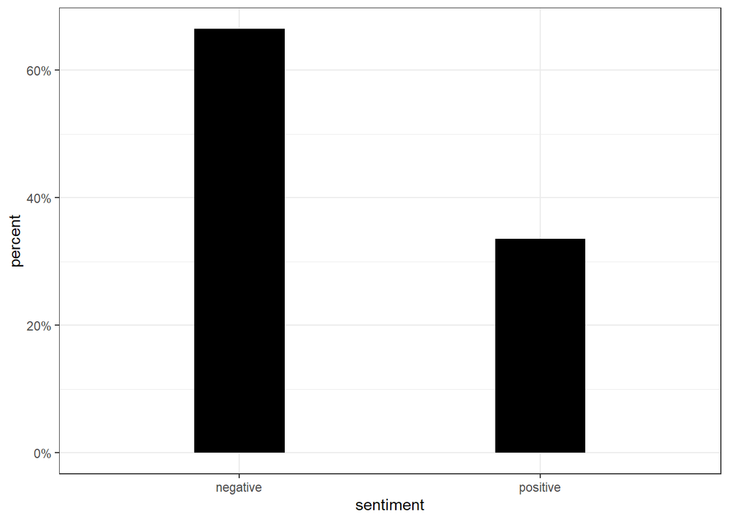

```r
titanic6 <- titanic6 %>%
  group_by(sentiment) %>%
  count(word, sort = TRUE) %>%
  summarise(total = sum(n))

titanic6 <- titanic6 %>%
  mutate(percent = total/sum(total)*100)

titanic6 %>%
  ggplot(aes(x = reorder(sentiment, -percent))) +
  geom_col(aes(y = percent), width = .3, fill = "black") +
  scale_y_continuous(labels = scales::percent_format(scale = 1)) +
  theme_bw() +
  xlab("sentiment")
```

The results obtained from the bing lexicon are similar to the results obtained after using the nrc lexicon. The negative words dominate.

To determine how the sentiments changed across the trajectory of the novel. the AFINN lexicon was used. The following graph was obtained;

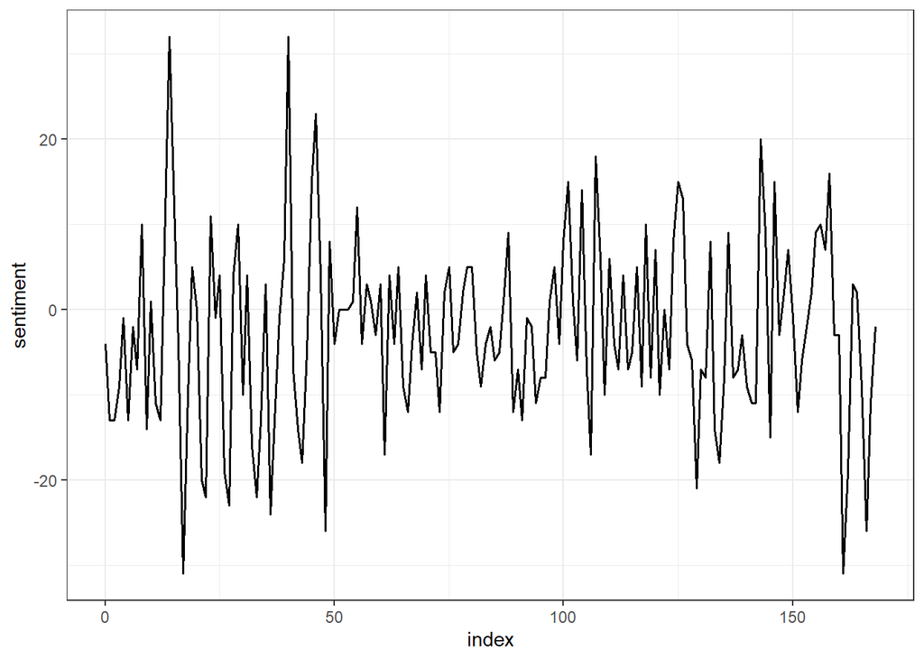

```r
titanic <- gutenberg_download(24880)
titanic <- titanic %>%
  mutate(linenumber = row_number(),
         chapter = cumsum(str_detect(text, regex("^chapter", ignore_case = TRUE))))

titanic <- titanic %>%
  unnest_tokens(word, text)

af <- get_sentiments("afinn")
titanic <- titanic %>%
  inner_join(af) %>%
  group_by(index = linenumber %/% 50) %>%
  summarise(sentiment = sum(value)) %>%
  mutate(method = "AFINN")

titanic %>%
  ggplot(aes(x = index)) +
  geom_line(aes(y = sentiment), fill= "black", linewidth = .6) +
  theme_bw()
```

From the plot above, the most positive and negative words are many at the start of the novel. This may be because of the situation when boarding the ship,some people could have used negative words due to occurrences such as delay. They could have also used positive words due to the joy of boarding the popular ship. The score of the words reduce or stabilize towards the center of the novel. At the end of the novel, most words become negative. This could be attributed by the sinking of the ship towards the end of the novel. The cursing, despair could attribute to the negative words.